# Enfermedades raras del sistema nervioso

Rubén Moreno, Álvaro Carbonell, Diego Tobes

```r
# Cargar el paquete RPostgres
library(DBI)
library(RPostgres)

# Conectar a la base de datos PostgreSQL
con <- dbConnect(RPostgres::Postgres(),
                 dbname = "Romisbases",  # Nombre de la base de datos
                 host = "localhost",           # Dirección del host
                 port = 5432,                  # Puerto de PostgreSQL
                 user = "postgres",          # Tu usuario de PostgreSQL
                 password = "1323")   # Tu contraseña de PostgreSQL
```

Vamos a realizar las siguientes

1. **Tabla ORPHA**: Contendrá datos de las enfermedades
2. **Tabla OMIM**: Contendrá datos sobre los genes de las enfermedades y la enfermedad
3. **Tabla NCBI**: Contendrá datos sobre el gen de la enfermedad

Responderemos las siguientes preguntas:

1. **Interpretación de la herencia**
2. **¿Número de isoformas posibles del gen?**
3. **¿Qué enfermedades tienen prevalencia rara, herencia autosómica recesiva y cuyos genes codifican proteínas?**
4. **¿En qué cromosomas hay más genes que provocan enfermedades?**

```sql
DROP VIEW IF EXISTS Isoformas
```

```sql
DROP TABLE IF EXISTS ORPHA, OMIM, NCBI;
```

### ORPHA

```sql
CREATE TABLE ORPHA (
      OMIM numeric(7) constraint fallo_por_pk_ORPHA PRIMARY KEY CHECK(OMIM>0),
    Orpha numeric(7) constraint no_se_permiten_Orpha_nulos NOT NULL CHECK(Orpha>0),
    Nombre char(100) constraint no_se_permiten_Nombres_nulos NOT NULL,
    Clasificacion varchar(100),
    Herencia varchar(35),
    Prevalencia varchar(50),
    Edad_inicio char(25)
);
```

### OMIM

```sql
CREATE TABLE OMIM(
    GenMIMn integer constraint fallo_por_pk_OMIM primary key CHECK(GenMIMn>0),
    Gen char (20) not null constraint fallo_por_unicidad_delGEN unique,
    PhenotypeMIMn integer not null CHECK(PhenotypeMIMn>0) constraint fallo_por_unicidad_phenotypeMIMn unique references ORPHA ON DELETE CASCADE,
    Localizacion varchar (50),
    Fenotipo char (100),
    Herencia varchar (50)
);
```

### NCBI

```sql
CREATE TABLE NCBI (
    FULLname char(100) constraint fallo_por_pk_NCBI PRIMARY KEY,
    Simbolo char(10) NOT NULL constraint fallo_por_unicidad_SIMBOLO UNIQUE REFERENCES OMIM(Gen) ON DELETE CASCADE,
    Tipo char(50),
    Organismo char(50),
    nExones integer CHECK(nExones>0),
    Refseq_estatus varchar(50) constraint no_se_permiten_RefseqESTATUS_nulos NOT NULL
);
```

### INSERTS ORPHA

```sql
INSERT INTO ORPHA (OMIM, Orpha, Nombre, Clasificacion, Herencia, Prevalencia, Edad_inicio) VALUES
(203450, 58, 'Enfermedad de Alexander', 'Trastorno neurodegenerativo', 'Autosómica dominante', 'Extremadamente rara', 'Infancia temprana'),
(602433, 357043, 'Esclerosis lateral amiotrófica tipo 4', 'Trastorno neuromuscular', 'Autosómica recesiva', 'Extremadamente rara', 'Adultos'),
(205100, 300605, 'Esclerosis lateral amiotrófica juvenil', 'Trastorno neuromuscular', 'Autosómica recesiva', 'Muy rara', 'Infancia'),
(602099, 300605, 'Esclerosis lateral amiotrófica juvenil', 'Trastorno neuromuscular', 'Autosómica recesiva', 'Muy rara', 'Infancia'),
(614373, 300605, 'Esclerosis lateral amiotrófica juvenil', 'Trastorno neuromuscular', 'Autosómica recesiva', 'Muy rara', 'Infancia'),
(139393, 2103, 'Síndrome de Guillain-Barré', 'Trastorno autoinmune', 'No genética', 'Rara', 'Desconocido'),
(157900, 570, 'Síndrome de Möbius', 'Trastorno neurológico', 'Esporádica', 'Muy rara', 'Infancia temprana'),
(143100, 399, 'Enfermedad de Huntington', 'Trastorno neurodegenerativo', 'Autosómica dominante', 'Rara', 'Adultos jóvenes'),
(162200, 636, 'Neurofibromatosis tipo 1', 'Trastorno genético', 'Autosómica dominante', 'Rara', 'Infancia'),
(101000, 634492, 'Schwannomatosis en mosaico', 'Trastorno genético', 'Autosómica dominante', 'Muy rara', 'Adultos jóvenes'),
(300100, 139396, 'Adrenoleucodistrofia cerebral ligada al X', 'Trastorno genético', 'Ligada al cromosoma X', 'Rara', 'Infancia'),
(229300, 95, 'Ataxia de Friedreich', 'Trastorno neurológico', 'Autosómica recesiva', 'Rara', 'Adolescencia'),
(601992, 95, 'Ataxia de Friedreich', 'Trastorno neurológico', 'Autosómica recesiva', 'Rara', 'Adolescencia'),
(146500, 102, 'Atrofia multisistémica', 'Trastorno neurodegenerativo', 'No genética', 'Rara', 'Adultos'),
(182980, 227510, 'Atrofia multisistémica tipo cerebeloso', 'Trastorno neurodegenerativo', 'No genética', 'Muy rara', 'Adultos'),
(310200, 98896, 'Distrofia muscular de Duchenne', 'Trastorno muscular', 'Ligada al cromosoma X', 'Rara', 'Infancia'),
(607208, 33069, 'Síndrome de Dravet', 'Trastorno genético', 'Autosómica dominante', 'Rara', 'Infancia temprana'),
(612164, 33069, 'Síndrome de Dravet', 'Trastorno genético', 'Autosómica dominante', 'Rara', 'Infancia temprana'),
(615744, 33069, 'Síndrome de Dravet', 'Trastorno genético', 'Autosómica dominante', 'Rara', 'Infancia temprana'),
(614212, 263524, 'Encefalopatía necrotizante aguda', 'Trastorno neurometabólico', 'Autosómica recesiva', 'Muy rara', 'Infancia'),
(122470, 228165, 'Esclerosis concéntrica de Balo', 'Variante de esclerosis múltiple', 'No genética', 'Extremadamente rara', 'Adultos'),
(105830, 73, 'Síndrome de Angelman', 'Trastorno neurogenético', 'Mutación en cromosoma 15', 'Rara', 'Infancia temprana'),
(312750, 778, 'Síndrome de Rett', 'Trastorno neurodesarrollo', 'Ligada al cromosoma X', 'Rara', 'Infancia temprana'),
(304050, 50, 'Síndrome de Aicardi', 'Trastorno del desarrollo', 'Ligada al cromosoma X', 'Extremadamente rara', 'Infancia temprana'),
(249900, 512, 'Leucodistrofia metacromática', 'Leucodistrofia', 'Autosómica recesiva', 'Rara', 'Infancia'),
(250100, 512, 'Leucodistrofia metacromática', 'Leucodistrofia', 'Autosómica recesiva', 'Rara', 'Infancia'),
(272800, 845, 'Enfermedad de Tay-Sachs', 'Enfermedad neurodegenerativa', 'Autosómica recesiva', 'Rara', 'Infancia'),
(260540, 683, 'Parálisis supranuclear progresiva', 'Enfermedad neurodegenerativa', 'Esporádica', 'Rara', 'Adultos'),
(619065, 70472, 'Deficiencia de COX-SLSJ', 'Enfermedad metabólica', 'Autosómica recesiva', 'Muy rara', 'Infancia'),
(220111, 70472, 'Deficiencia de COX-SLSJ', 'Enfermedad metabólica', 'Autosómica recesiva', 'Muy rara', 'Infancia'),
(213600, 1980, 'Enfermedad de Fahr', 'Enfermedad neurodegenerativa', 'Desconocida', 'Rara', 'Adultos jóvenes'),
(614753, 420179, 'Síndrome de Sotos', 'Trastorno genético', 'Autosómica dominante', 'Rara', 'Infancia'),
(203700, 726, 'Síndrome de Alpers', 'Enfermedad neurodegenerativa', 'Autosómica recesiva', 'Rara', 'Infancia'),
(271900, 141, 'Enfermedad de Canavan', 'Leucodistrofia', 'Autosómica recesiva', 'Rara', 'Infancia temprana'),
(109150, 98757, 'Enfermedad de SCA', 'Enfermedad neurodegenerativa', 'Autosómica dominante', 'Rara', 'Adultos jóvenes'),
(245570, 98818, 'Síndrome de Landau-Kleffner', 'Trastorno del desarrollo', 'Esporádica', 'Rara', 'Infancia temprana');
```

### inserts de OMIM

```sql
INSERT INTO OMIM (Gen, PhenotypeMIMn, Localizacion, Fenotipo, GenMIMn, Herencia) VALUES
('GFAP', 203450, 'Cromosoma 17', 'Enfermedad de Alexander', 137780, 'AD'),
('SETX', 602433, 'Cromosoma 21', 'Esclerosis lateral amiotrófica tipo 4', 608465, 'AR'),
('ALS2', 205100, 'Cromosoma 21', 'Esclerosis lateral amiotrófica juvenil', 606352, 'AR'),
('SPG11', 602099, 'Cromosoma 21', 'Esclerosis lateral amiotrófica juvenil', 610844, 'AR'),
('SIGMAR1', 614373, 'Cromosoma 21', 'Esclerosis lateral amiotrófica juvenil', 601978, 'AR'),
('PMP22', 139393, 'Cromosoma 2', 'Síndrome de Guillain-Barré', 601097, 'No genética'),
('MOBY', 157900, 'Cromosoma 13', 'Síndrome de Möbius', 157900, 'Esporádica'),
('HTT', 143100, 'Cromosoma 4', 'Enfermedad de Huntington', 613004, 'AD'),
('NF1', 162200, 'Cromosoma 17', 'Neurofibromatosis tipo 1', 613113, 'AD'),
('NF2', 101000, 'Cromosoma 22', 'Schwannomatosis en mosaico', 607379, 'AD'),
('ABCD1', 300100, 'Cromosoma X', 'Adrenoleucodistrofia cerebral ligada al X', 300371, 'Ligada al cromosoma X'),
('FXN', 229300, 'Cromosoma 9', 'Ataxia de Friedreich', 606829, 'AR'),
('FRDA', 601992, 'Cromosoma 9', 'Ataxia de Friedreich', 601992, 'AR'),
('COQ2', 146500, 'Cromosoma 1', 'Atrofia multisistémica', 609825, 'No genética'),
('VAPBC', 182980, 'Cromosoma 1', 'Atrofia multisistémica tipo cerebeloso', 605704, 'No genética'),
('DMD', 310200, 'Cromosoma X', 'Distrofia muscular de Duchenne', 300377, 'Ligada al cromosoma X'),
('SCN1A', 607208, 'Cromosoma 2', 'Síndrome de Dravet', 182389, 'AD'),
('STXBP1', 612164, 'Cromosoma 2', 'Síndrome de Dravet', 602926, 'AD'),
('SGABRA1', 615744, 'Cromosoma 2', 'Síndrome de Dravet', 137160, 'AD'),
('CPT2', 614212, 'Cromosoma 16', 'Encefalopatía necrotizante aguda', 600650, 'AR'),
('NIPBL', 122470, 'Cromosoma 1', 'Esclerosis concéntrica de Balo',608667, 'No genética'),
('UBE3A', 105830, 'Cromosoma 15', 'Síndrome de Angelman', 601623, 'AD'),
('MECP2', 312750, 'Cromosoma X', 'Síndrome de Rett', 3300005, 'Ligada al cromosoma X'),
('AICD', 304050, 'Cromosoma X', 'Síndrome de Aicardi', 304050, 'Ligada al cromosoma X'),
('PSAP', 249900, 'Cromosoma 22', 'Leucodistrofia metacromática', 176801, 'AR'),
('ARSA', 250100, 'Cromosoma 22', 'Leucodistrofia metacromática',    607574, 'AR'),
('HEXA', 272800, 'Cromosoma 15', 'Enfermedad de Tay-Sachs', 606869, 'AR'),
('MAPT', 260540, 'Cromosoma 17', 'Parálisis supranuclear progresiva', 607141, 'Esporádica'),
('COXFA4', 619065, 'Cromosoma 6', 'Deficiencia de COX-SLSJ', 603833, 'AR'),
('LRPPRC', 220111, 'Cromosoma 6', 'Deficiencia de COX-SLSJ', 607544, 'AR'),
('SLC20A2', 213600, 'Cromosoma 14', 'Enfermedad de Fahr', 158378, 'Desconocida'),
('NFIX', 614753, 'Cromosoma 20', 'Síndrome de Sotos', 164005, 'AD'),
('POLG', 203700, 'Cromosoma 15', 'Síndrome de Alpers', 203700, 'AR'),
('ASPA', 271900, 'Cromosoma 17', 'Enfermedad de Canavan',   608034, 'AR'),
('ATXN3', 109150, 'Cromosoma 6', 'Enfermedad de SCA', 607047, 'AD'),
('GRIN2A', 245570, 'Cromosoma 12', 'Síndrome de Landau-Kleffner', 138253, 'Esporádica');
```

### inserts NCBI

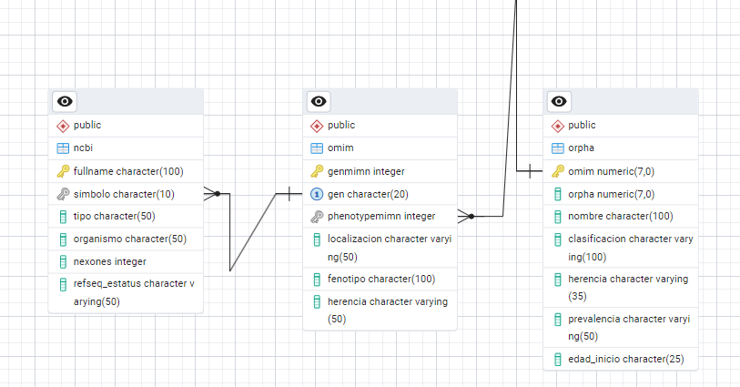

```sql
INSERT INTO NCBI (FULLname, Simbolo, Tipo, Organismo, nExones, Refseq_estatus) VALUES
('Glial Fibrillary Acidic Protein', 'GFAP', 'Intermediate Filament', 'Human', 9, 'Reviewed'),
('Senataxin', 'SETX', 'Helicase', 'Human', NULL, 'Reviewed'),
('Alsin Rho Guanine Nucleotide Exchange Factor', 'ALS2', 'Guanine Nucleotide Exchange Factor', 'Human', 34, 'Reviewed'),
('Spatacsin', 'SPG11', 'Protein Coding', 'Human', 40, 'Reviewed'),
('Sigma Non-Opioid Intracellular Receptor 1', 'SIGMAR1', 'Receptor', 'Human', 4, 'Reviewed'),
('Peripheral Myelin Protein 22', 'PMP22', 'Protein Coding', 'Human', NULL, 'Reviewed'),
('Moby-Like Protein', 'MOBY', 'Protein Coding', 'Human', NULL, 'Reviewed'),
('Huntingtin', 'HTT', 'Protein Coding', 'Human', 67, 'Reviewed'),
('Neurofibromin 1', 'NF1', 'Tumor Suppressor', 'Human', 60, 'Reviewed'),
('Neurofibromin 2', 'NF2', 'Tumor Suppressor', 'Human', 17, 'Reviewed'),
('ATP Binding Cassette Subfamily D Member 1', 'ABCD1', 'Transporter', 'Human', 10, 'Reviewed'),
('Frataxin', 'FXN', 'Protein Coding', 'Human', 6, 'Reviewed'),
('Frataxin Related', 'FRDA', 'Protein Coding', 'Human', NULL, 'Reviewed'),
('Coenzyme Q2', 'COQ2', 'Decarboxylase', 'Human', 7, 'Reviewed'),
('VAMP-Associated Protein B and C', 'VAPBC', 'Protein Coding', 'Human', 2, 'Reviewed'),
('Dystrophin', 'DMD', 'Structural', 'Human', 79, 'Reviewed'),
('Sodium Voltage-Gated Channel Alpha Subunit 1', 'SCN1A', 'Ion Channel', 'Human', 26, 'Reviewed'),
('Syntaxin Binding Protein 1', 'STXBP1', 'Protein Coding', 'Human', 20, 'Reviewed'),
('Gamma-Aminobutyric Acid Type A Receptor Alpha1 Subunit', 'SGABRA1', 'Receptor', 'Human', 9, 'Reviewed'),
('Carnitine Palmitoyltransferase 2', 'CPT2', 'Enzyme', 'Human', 5, 'Reviewed'),
('Nipped-B Like', 'NIPBL', 'Cohesin Loading Factor', 'Human', 47, 'Reviewed'),
('Ubiquitin Protein Ligase E3A', 'UBE3A', 'Ligase', 'Human', 16, 'Reviewed'),
('Methyl CpG Binding Protein 2', 'MECP2', 'Methyl Binding Protein', 'Human', 4, 'Reviewed'),
('APP Intracellular Domain', 'AICD', 'Protein Coding', 'Human', NULL, 'Reviewed'),
('Prosaposin', 'PSAP', 'Protein Coding', 'Human', 15, 'Reviewed'),
('Arylsulfatase A', 'ARSA', 'Enzyme', 'Human', 8, 'Reviewed'),
('Hexosaminidase Subunit Alpha', 'HEXA', 'Enzyme', 'Human', 14, 'Reviewed'),
('Microtubule Associated Protein Tau', 'MAPT', 'Microtubule Binding', 'Human', 16, 'Reviewed'),
('Cytochrome C Oxidase Subunit 4A', 'COXFA4', 'Enzyme', 'Human', NULL, 'Reviewed'),
('Leucine-Rich Pentatricopeptide Repeat Containing', 'LRPPRC', 'Protein Coding', 'Human', 35, 'Reviewed'),
('Solute Carrier Family 20 Member 2', 'SLC20A2', 'Transporter', 'Human', 7, 'Reviewed'),
('Nuclear Factor I X', 'NFIX', 'Transcription Factor', 'Human', 11, 'Reviewed'),
('DNA Polymerase Gamma Catalytic Subunit', 'POLG', 'DNA Polymerase', 'Human', 23, 'Reviewed'),
('Aspartoacylase', 'ASPA', 'Enzyme', 'Human', 7, 'Reviewed'),
('Ataxin 3', 'ATXN3', 'Protein Coding', 'Human', 11, 'Reviewed'),
('Glutamate Ionotropic Receptor NMDA Type Subunit 2A', 'GRIN2A', 'Receptor', 'Human', 16, 'Reviewed');
```

DIAGRAMA EDR DE LAS RELACIONES USADAS

## ENFERMEDADES RARAS DEL SISTEMA NERVIOSO

Vamos a comparar diferentes caracteristicas enfermedades raras del sistema nervioso y los genes que influyen a estas

### INTERPRETACION DE LA HERENCIA

Mediante la combinacion de un inner join y un case-when observamos en que cromosomas se encuentran los genes y hemos realizado una simple interpretacion de sus herencias.

Destacamos el hecho de que existen enfermedades que son provocadas por cambios temporales en los genes, lo que hace que no se consideren estrictamente como enfermedades genéticas. Estos cambios pueden ser influenciados por factores externos como la exposición a toxinas, radiación u otros factores ambientales. Aunque los cambios en el material genético juegan un papel en el desarrollo de la enfermedad, la causa subyacente no es hereditaria, sino que está relacionada con factores que alteran temporalmente la expresión genética.

```sql
SELECT Nombre, localizacion, ORPHA.herencia,
CASE
WHEN ORPHA.herencia = 'Ligada al cromosoma X' THEN 'en los cromosomas sexuales'
WHEN ORPHA.herencia = 'No genética' THEN 'No hay cambio permanente en el ADN.'
WHEN ORPHA.herencia ='Esporádica' THEN 'no siempre en el mismo sitio'
WHEN ORPHA.herencia ='Desconocida' THEN 'no se conoce su herencia'
ELSE 'en los cromosomas autosomicos'
END as interpretacion_de_la_herencia
FROM ORPHA JOIN OMIM ON(OMIM=PhenotypeMIMn)
WHERE ORPHA.herencia != 'Autosómica recesiva'
```

Displaying records 1 - 10

| nombre | localizacion | herencia | interpretacion_de_la_herencia |
| --- | --- | --- | --- |
| Enfermedad de Alexander | Cromosoma 17 | Autosómica dominante | en los cromosomas autosomicos |
| Síndrome de Guillain-Barré | Cromosoma 2 | No genética | No hay cambio permanente en el ADN. |
| Síndrome de Möbius | Cromosoma 13 | Esporádica | no siempre en el mismo sitio |
| Enfermedad de Huntington | Cromosoma 4 | Autosómica dominante | en los cromosomas autosomicos |
| Neurofibromatosis tipo 1 | Cromosoma 17 | Autosómica dominante | en los cromosomas autosomicos |
| Schwannomatosis en mosaico | Cromosoma 22 | Autosómica dominante | en los cromosomas autosomicos |
| Adrenoleucodistrofia cerebral ligada al X | Cromosoma X | Ligada al cromosoma X | en los cromosomas sexuales |
| Atrofia multisistémica | Cromosoma 1 | No genética | No hay cambio permanente en el ADN. |
| Atrofia multisistémica tipo cerebeloso | Cromosoma 1 | No genética | No hay cambio permanente en el ADN. |
| Distrofia muscular de Duchenne | Cromosoma X | Ligada al cromosoma X | en los cromosomas sexuales |

### NUMERO DE ISOFORMAS POSIBLES DEL GEN

Queremos añadir una columna a la tabla NCBI que nos clasifique el tamaño de los exones en funcion de la cantidad que tenga el gen y queremos crear una tabla no permanente es decir una vista en la que se nos indica una estimacion de las posibles isoformas del gen.

Bien para añadir esta nueva columna a nuestra tabla NCBI, lo primero que hemos hecho es alterar el tamaño de nuestra tabla añadiendo una columna más con el nombre de ‘Tamaño’; a partir de aqui modificamos esta columna nueva añadida con un case, que en función del número de exones nos dará una especificación acerca de cómo es el tamaño de los exones. Por último, creamos una vista, en la que en su interior contenga el número de isoformas posibles de cada gen, hemos escogido solo aquellos genes clasificados como cortos o intermedios.

```sql
Alter table NCBI
Add column Tamaño varchar(20);
```

```sql
Update NCBI
set Tamaño = Case
        When nExones < 15 then 'Muy Cortas'
        when nExones < 30 then 'Cortas'
        when nExones < 45 then 'Intermedias'
        when nExones < 60 then 'Largas'
        when nExones >= 60 then 'Muy Largas'
        else 'Tamaño desconocido'
End;
```

```sql
Create view Isoformas (FULLname, Simbolo, nExones, tamaño, nIsoformas) AS
select FULLname, Simbolo, nExones, tamaño, power(2, nExones)-1
from NCBI JOIN OMIM ON(Simbolo=Gen)
JOIN ORPHA ON(PhenotypeMIMn=OMIM)
where tamaño= 'Cortas' or tamaño= 'Intermedias'
ORDER BY nExones
```

```sql
Select * from Isoformas
```

Displaying records 1 - 10

| fullname | simbolo | nexones | tamaño | nisoformas |
| --- | --- | --- | --- | --- |
| Prosaposin | PSAP | 15 | Cortas | 32767 |
| Glutamate Ionotropic Receptor NMDA Type Subunit 2A | GRIN2A | 16 | Cortas | 65535 |
| Ubiquitin Protein Ligase E3A | UBE3A | 16 | Cortas | 65535 |
| Microtubule Associated Protein Tau | MAPT | 16 | Cortas | 65535 |
| Neurofibromin 2 | NF2 | 17 | Cortas | 131071 |
| Syntaxin Binding Protein 1 | STXBP1 | 20 | Cortas | 1048575 |
| DNA Polymerase Gamma Catalytic Subunit | POLG | 23 | Cortas | 8388607 |
| Sodium Voltage-Gated Channel Alpha Subunit 1 | SCN1A | 26 | Cortas | 67108863 |
| Alsin Rho Guanine Nucleotide Exchange Factor | ALS2 | 34 | Intermedias | 17179869183 |
| Leucine-Rich Pentatricopeptide Repeat Containing | LRPPRC | 35 | Intermedias | 34359738367 |

### ENFERMEDADES CON PREVALENCIA RARA, HERENCIA AUTOSOMICA RECESIVA Y CUYOS GENES CODIFICAN PROTEINAS

Queremos obtener el nombre, la edad de inicio (aparición) y el gen de una enfermedad en funcion de su prevalencia, de su tipo de herencia y del tipo. Para ello, seleccionamos lo que queremos y hacemos varios joins, en los cuales juntamos las tablas omim con orpha a traves de los atributos OMIM y PhenotypeMIMn. En el otro join, juntamos las tablas NCBI y la OMIM a traves del Gen y el Simbolo. Asi, una vez unidas las tablas y dicho lo que queremos obtener, simplemente ponemos el “filtro” where para indicar las condiciones por las cuales queremos que se obtengan los atributos pedidos.

```sql
SELECT NCBI.Fullname AS Nombrecompleto, OMIM.Gen AS Gen, ORPHA.Edad_inicio AS Edad_aparición
FROM ORPHA
JOIN OMIM ON ORPHA.OMIM = OMIM.PhenotypeMIMn
JOIN NCBI ON OMIM.Gen = NCBI.Simbolo
WHERE ORPHA.Prevalencia='Rara'
AND OMIM.Herencia='AR'
AND NCBI.Tipo='Protein Coding';
```

3 records

| nombrecompleto | gen | edad_aparición |
| --- | --- | --- |
| Frataxin | FXN | Adolescencia |
| Frataxin Related | FRDA | Adolescencia |
| Prosaposin | PSAP | Infancia |

### CROMOSOMAS EN LOS QUE HAY MAYOR CANTIDAD DE GENES QUE PROVOCAN ENFERMEDADES

Mediante el uso del count distict, el gruop by y el having contare el numero de enfermedades agrupadas en cada cromosoma y filtraremos aquellas en las que el el numero de enfermedades cuyos genes en el cromosoma es mayor que uno para finalizar empleo un order by descendente para que se ordenen de mas a menos

```sql
SELECT DISTINCT Localizacion, COUNT(DISTINCT Nombre) AS Total_Enfermedades
FROM OMIM JOIN ORPHA ON(OMIM.PhenotypeMIMn = ORPHA.OMIM)
GROUP BY OMIM.Localizacion
HAVING COUNT(DISTINCT Nombre)>1
ORDER BY Total_Enfermedades DESC;
```

8 records

| localizacion | total_enfermedades |
| --- | --- |
| Cromosoma 17 | 4 |
| Cromosoma X | 4 |
| Cromosoma 1 | 3 |
| Cromosoma 15 | 3 |
| Cromosoma 2 | 2 |
| Cromosoma 21 | 2 |
| Cromosoma 22 | 2 |
| Cromosoma 6 | 2 |

```r
# Obtener la lista de todas las tablas en la base de datos
tables <- dbListTables(con)
print(tables)
```

```
## [1] "ncbi"      "omim"      "orpha"     "isoformas"
```

```r
# Borrar todas las tablas
for (table in tables) {
  dbExecute(con, paste0("DROP TABLE IF EXISTS ", table, " CASCADE;"))
}

# Verificar que no queden tablas
tables_after <- dbListTables(con)
print(tables_after)
```

```
## character(0)
```

```r
# Cerrar la conexión
dbDisconnect(con)
```